# Project

```python
import warnings
warnings.filterwarnings("ignore")
```

```python
pip install shap
```

[output not shown]

```python
import pandas as pd
import numpy as np
import matplotlib.pyplot as plt
import seaborn as sns

import pandas as pd
import numpy as np
import matplotlib.pyplot as plt
import shap
from sklearn.model_selection import GridSearchCV
from sklearn.svm import SVR
from sklearn.pipeline import Pipeline
from sklearn.preprocessing import StandardScaler
from sklearn.feature_selection import SelectKBest, f_regression
pd.set_option('display.max_columns', None)
from sklearn.model_selection import train_test_split
from sklearn.ensemble import RandomForestRegressor
from sklearn.metrics import r2_score
from sklearn.feature_selection import r_regression
from scipy import stats
import subprocess
from sklearn.model_selection import cross_val_score, KFold
from sklearn.model_selection import cross_val_predict
from sklearn.model_selection import train_test_split
from sklearn.metrics import make_scorer
from sklearn.metrics import mean_squared_error
```

```python
# 1. imprort Data
df= pd.read_csv(r'data/train_df.csv')
test= pd.read_csv(r'data/test_no_target.csv')
```

```python
df.isna().sum()
```

```
index_h                                  0
time                                     0
generation biomass                      14
generation fossil brown coal/lignite    14
generation fossil coal-derived gas      14
                                        ..
snow_3h_Seville                          0
clouds_all_Seville                       0
weather_id_Seville                       0
weather_main_Seville                     0
weather_description_Seville              0
Length: 99, dtype: int64
```

# 2. Clean Data

2.1 null values -

1. data types
2. outliers
3. dummy variables
4. drop unrelated columns

## 2.1 null values

1. I'l drop columns with more than 30 % of the data is null -forecast wind offshore eday ahead ,generation hydro pumped storage aggregated
   1. impute by interpolate

```python
df.drop(columns=['forecast wind offshore eday ahead','generation hydro pumped storage aggregated'], inplace=True)
df = df.interpolate(method='linear', limit_direction='forward', axis=0)
```

```python
print("sum of null values:",df.isna().sum().sum())
```

```
sum of null values: 0
```

## 2.2 data types

I'll convert the next column to informative data type (the goal is that all the clolumn will be int, float or string)

1. time - change to column of hour
2. create dummy features: 'weather_main_Valencia", 'weather_description_Valencia','weather_id_Valencia', 'weather_main_Madrid', ''weather_id_Madrid',"weather_description_Madrid', 'weather*main* Barcelona','weather*id* Barcelona','weather*description* Barcelona', 'weather_main_Bilbao','weather_id_Bilbao',''weather_description_Bilbao', 'weather_main_Seville','weather_description_Seville ','weather_description_Seville' ,'hour','day','month'

```python
def create_dummy_variables(df, column_name):
    # Create dummy variables for the specified column
    dummies = pd.get_dummies(df[column_name], prefix=column_name)

    # Merge the dummy variables with the original DataFrame
    df = pd.concat([df, dummies], axis=1)

    # Drop the original column from the DataFrame
    df.drop(column_name, axis=1, inplace=True)

    return df
```

```python
df["time"]=pd.to_datetime(df["time"])
df['hour']=df["time"].apply(lambda x: x.hour)
df['day']=df["time"].apply(lambda x: x.weekday())
df.drop(columns=['time'],inplace=True)
```

```python
list_column_dummy=['weather_main_Valencia', 'weather_description_Valencia','weather_id_Valencia', 'weather_main_Madrid', 'weather_id_Madrid','weather_description_Madrid', 'weather_main_ Barcelona','weather_id_ Barcelona','weather_description_ Barcelona',
'weather_main_Bilbao','weather_id_Bilbao','weather_description_Bilbao',
'weather_main_Seville','weather_description_Seville' ,'hour','day','month']
for name in list_column_dummy:
    df=create_dummy_variables(df,name)
```

```python
#drop index_h column
df.drop(columns='index_h',inplace=True)
```

# 3. Data Engineering

1. create total generation column- the column sum all the procudced electricity
2. create total forecast colum- the column sum all the forecast electricity

```python
df['total_generation'] = df.iloc[:, 1:21].sum(axis=1)
df['total_forecast'] = df.iloc[:, 21:23].sum(axis=1)
```

# 4. EDA

1. create heaetmap which give details on correlation
2. create histogram of the the price
3. drop irrelaevnt features

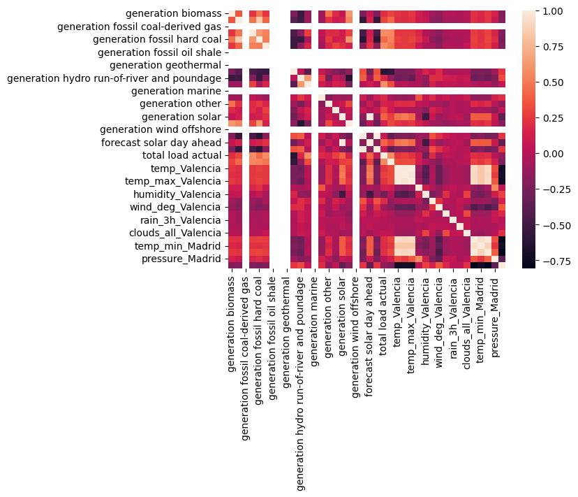

```python
df_temp=df.iloc[:,:40]
sns.heatmap(df_temp.corr())
```

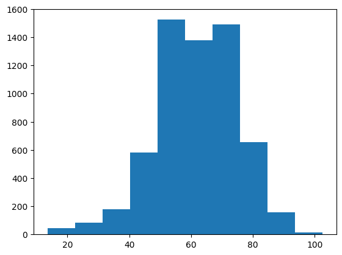

```python
plt.hist(df["price actual"])
```

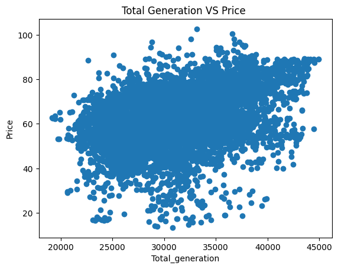

```python
x=df["total_generation"]
y=df["price actual"]
plt.scatter(x, y)

# Add labels and title
plt.xlabel('Total_generation')
plt.ylabel('Price')
plt.title('Total Generation VS Price ')

# Display the plot
plt.show()
```

```python
# Assuming you have a DataFrame called 'df'
correlation_matrix = df.corr()

# Find columns with correlation scores less than 0.22
low_correlation_columns = correlation_matrix[np.abs(correlation_matrix["price actual"])<0.22].index
# Drop columns with low correlation scores
df.drop(low_correlation_columns, axis=1, inplace=True)

# Print the updated DataFrame or use it as needed
df
```

|  | generation biomass | generation fossil brown coal/lignite | generation fossil coal-derived gas | generation fossil gas | generation fossil hard coal | generation fossil oil | generation fossil oil shale | generation fossil peat | generation geothermal | generation hydro pumped storage consumption | generation hydro water reservoir | generation marine | generation solar | generation waste | generation wind offshore | generation wind onshore | forecast solar day ahead | forecast wind onshore day ahead | total load actual | price actual | temp_Valencia | temp_min_Valencia | temp_max_Valencia | temp_Madrid | temp_min_Madrid | temp_max_Madrid | humidity_Madrid | snow_3h_Madrid | temp_Bilbao | … |
| --- | --- | --- | --- | --- | --- | --- | --- | --- | --- | --- | --- | --- | --- | --- | --- | --- | --- | --- | --- | --- | --- | --- | --- | --- | --- | --- | --- | --- | --- | --- |
| 0 | 447.0 | 329.0 | 0.0 | 4844.0 | 4821.0 | 162.0 | 0.0 | 0.0 | 0.0 | 863.0 | 1899.0 | 0.0 | 49.0 | 196.0 | 0.0 | 6378.0 | 17 | 6436 | 25385.0 | 65.41 | 270.475 | 270.475 | 270.475 | 267.325 | 267.325 | 267.325 | 63 | 0 | 269.657312 | … |
| 1 | 449.0 | 328.0 | 0.0 | 5196.0 | 4755.0 | 158.0 | 0.0 | 0.0 | 0.0 | 920.0 | 1658.0 | 0.0 | 50.0 | 195.0 | 0.0 | 5890.0 | 16 | 5856 | 24382.0 | 64.92 | 270.475 | 270.475 | 270.475 | 267.325 | 267.325 | 267.325 | 63 | 0 | 269.763500 | … |
| 2 | 448.0 | 323.0 | 0.0 | 4857.0 | 4581.0 | 157.0 | 0.0 | 0.0 | 0.0 | 1164.0 | 1371.0 | 0.0 | 50.0 | 196.0 | 0.0 | 5461.0 | 8 | 5454 | 22734.0 | 64.48 | 269.686 | 269.686 | 269.686 | 266.186 | 266.186 | 266.186 | 64 | 0 | 269.251688 | … |
| 3 | 438.0 | 254.0 | 0.0 | 4314.0 | 4131.0 | 160.0 | 0.0 | 0.0 | 0.0 | 1503.0 | 779.0 | 0.0 | 50.0 | 191.0 | 0.0 | 5238.0 | 2 | 5151 | 21286.0 | 59.32 | 269.686 | 269.686 | 269.686 | 266.186 | 266.186 | 266.186 | 64 | 0 | 269.203344 | … |
| 4 | 428.0 | 187.0 | 0.0 | 4130.0 | 3840.0 | 156.0 | 0.0 | 0.0 | 0.0 | 1826.0 | 720.0 | 0.0 | 42.0 | 189.0 | 0.0 | 4935.0 | 9 | 4861 | 20264.0 | 56.04 | 269.686 | 269.686 | 269.686 | 266.186 | 266.186 | 266.186 | 64 | 0 | 269.485500 | … |
| ... | ... | ... | ... | ... | ... | ... | ... | ... | ... | ... | ... | ... | ... | ... | ... | ... | ... | ... | ... | ... | ... | ... | ... | ... | ... | ... | ... | ... | ... | … |
| 6104 | 535.0 | 946.0 | 0.0 | 8520.0 | 7082.0 | 417.0 | 0.0 | 0.0 | 0.0 | 2.0 | 2549.0 | 0.0 | 485.0 | 257.0 | 0.0 | 4420.0 | 629 | 4557 | 33521.0 | 64.97 | 293.810 | 293.150 | 294.260 | 287.460 | 273.150 | 292.150 | 52 | 0 | 290.280000 | … |
| 6105 | 505.0 | 845.0 | 0.0 | 8568.0 | 6547.0 | 398.0 | 0.0 | 0.0 | 0.0 | 1.0 | 2676.0 | 0.0 | 1030.0 | 239.0 | 0.0 | 3572.0 | 1318 | 3928 | 31364.0 | 64.63 | 296.650 | 295.150 | 297.590 | 288.400 | 273.150 | 294.820 | 46 | 0 | 291.580000 | … |
| 6106 | 540.0 | 899.0 | 0.0 | 8751.0 | 6959.0 | 416.0 | 0.0 | 0.0 | 0.0 | 2.0 | 2579.0 | 0.0 | 1607.0 | 260.0 | 0.0 | 3506.0 | 1807 | 3520 | 33573.0 | 65.89 | 297.680 | 297.040 | 298.150 | 289.740 | 273.150 | 295.150 | 37 | 0 | 293.770000 | … |
| 6107 | 540.0 | 898.0 | 0.0 | 8879.0 | 6909.0 | 425.0 | 0.0 | 0.0 | 0.0 | 2.0 | 2080.0 | 0.0 | 1861.0 | 258.0 | 0.0 | 3048.0 | 1924 | 3211 | 33352.0 | 64.47 | 299.330 | 298.450 | 299.820 | 290.290 | 273.150 | 296.150 | 38 | 0 | 294.840000 | … |
| 6108 | 520.0 | 906.0 | 0.0 | 9016.0 | 6965.0 | 406.0 | 0.0 | 0.0 | 0.0 | 7.0 | 2250.0 | 0.0 | 1831.0 | 257.0 | 0.0 | 2787.0 | 1876 | 2869 | 33219.0 | 63.46 | 299.410 | 297.590 | 300.370 | 290.700 | 273.150 | 297.150 | 36 | 0 | 295.190000 | … |

6109 rows × 44 columns

# 5. ML implementation

```python
X=df.drop(columns='price actual')
y=df['price actual']
X_train, X_test, y_train, y_test = train_test_split( X, y, test_size=0.3, random_state=42)
```

```python
# hyper tuning optamization SVR
scaler = StandardScaler()
param_grid = {
    'svr__kernel': ['linear', 'poly', 'rbf'],
    'svr__C': [10, 50, 100,75],
    'svr__epsilon': [0.1, 0.01,0.2]}

pipe = Pipeline(steps=[("scaler", scaler), ("svr", SVR())])

reg = GridSearchCV(pipe, param_grid,cv=5,scoring='neg_root_mean_squared_error',verbose=1)
reg.fit(X_train,y_train)
reg.best_params_
```

```
Fitting 5 folds for each of 36 candidates, totalling 180 fits
```

```
{'svr__C': 100, 'svr__epsilon': 0.2, 'svr__kernel': 'rbf'}
```

```python
#standartization
scaler = StandardScaler()
X_train_std=scaler.fit_transform(X_train)
X_train=pd.DataFrame(data=X_train_std,columns=X_train.columns)
X_test_std=scaler.transform(X_test)
X_test=pd.DataFrame(data=X_test_std,columns=X_test.columns)
```

```python
#SVR
regsvr = SVR(C=100,epsilon=0.2,kernel='rbf')
regsvr.fit(X_train, y_train)
pred_SVR=regsvr.predict(X_test)
print(stats.spearmanr(y_test, pred_SVR))
print(stats.pearsonr(y_test, pred_SVR))
print(mean_squared_error(y_test,pred_SVR,squared=False))
```

```
SpearmanrResult(correlation=0.941046623235992, pvalue=0.0)
PearsonRResult(statistic=0.9492667085943058, pvalue=0.0)
4.081881330870218
```

```python
#random forest regressor
regr = RandomForestRegressor(max_depth=7,random_state=0,n_estimators=250)
regr.fit(X_train, y_train)
pred_rfr=regr.predict(X_test)
print(stats.spearmanr(y_test, pred_rfr))
print(stats.pearsonr(y_test, pred_rfr))
print(mean_squared_error(y_test,pred_rfr,squared=False))
```

```
SpearmanrResult(correlation=0.8587871882097061, pvalue=0.0)
PearsonRResult(statistic=0.8660024770908719, pvalue=0.0)
6.596657726863468
```

# 6. Export test data

in the next section we build function that pre-processed the test data , then implement the model over the test data and export it as csv

```python
def preprocess_data(df_t,train_df,low_correlation_columns,keep_columns):
    """
    function that take the raw data and pre-process it to cleaned and modified data for the ML model
    params: df= test dataframe
            train_Df= original dataframe
            low_correlation_columns- list of columns with low correlation
    return: cleaned and modified dataframe
    """
    # the df modification- the detaild describtion is during the jupyter notebbok
    #drop columns
    df_t.drop(columns=['forecast wind offshore eday ahead','generation hydro pumped storage aggregated'], inplace=True)
    df_t = df = df_t.interpolate(method='linear', limit_direction='forward', axis=0)
    #create new features
    df_t["time"]=pd.to_datetime(df_t["time"])
    df_t['hour']=df_t["time"].apply(lambda x: x.hour)
    df_t['day']=df_t["time"].apply(lambda x: x.weekday())
    df_t.drop(columns=['time'],inplace=True)
    #create dummy variables
    list_column_dummy=['weather_main_Valencia', 'weather_description_Valencia','weather_id_Valencia', 'weather_main_Madrid', 'weather_id_Madrid','weather_description_Madrid', 'weather_main_ Barcelona','weather_id_ Barcelona','weather_description_ Barcelona',
    'weather_main_Bilbao','weather_id_Bilbao','weather_description_Bilbao',
    'weather_main_Seville','weather_description_Seville' ,'hour','day','month']
    for name in list_column_dummy:
        df_t=create_dummy_variables(df_t,name)
    df_t.drop(columns='index_h',inplace=True)
    df_t['total_generation'] = df_t.iloc[:, 1:21].sum(axis=1)
    df_t['total_forecast'] = df_t.iloc[:, 21:23].sum(axis=1)
    #drop index_h column
    #drop low_correlation_columns
    for column in low_correlation_columns:
        try:
            df_t.drop(column, axis=1, inplace=True)
        except:
            continue
    #drop columns that doesnt exist in the original df
    df_t=df_t.loc[:,keep_columns]
    return df_t
```

```python
# assert preprocess function is working
keep_columns=X_train.columns.tolist()
#import data
test= pd.read_csv(r'data/test_no_target.csv')
train_df= pd.read_csv(r'data/train_df.csv')
processed_train=preprocess_data(train_df,train_df,low_correlation_columns,keep_columns)
X_train_process=processed_train
#check the data procesing is going well
assert X_train_process.columns.tolist() == X_train.columns.tolist(), "Columns are not the same"
assert X_train_process.equals(df.drop(columns=['price actual'])), "Dataframes ascalernot the same"
```

```python
#import df train and test
test= pd.read_csv(r'data/test_no_target.csv')
processed_test=preprocess_data(test,train_df,low_correlation_columns,keep_columns)
```

```python
#train new model with all the train dataframe, then preidct the test data set price
X_train=X_train_process
y_train=df['price actual']
#standartization
scaler = StandardScaler()
X_train_std=scaler.fit_transform(X_train)
X_train=pd.DataFrame(data=X_train_std,columns=X_train.columns)
processed_test_std=scaler.transform(processed_test)
processed_test=pd.DataFrame(data=processed_test_std,columns=processed_test.columns)
#ML model
regsvr = SVR(C=100,epsilon=0.2,kernel='rbf')
regsvr.fit(X_train, y_train)
pred_SVR=regsvr.predict(processed_test)
```

```python
# export the new csv file with the prediction
test = pd.read_csv(r'data/test_no_target.csv')
test["price predicted"] = pred_SVR
submit_test = test[['index_h', 'price predicted']]
submit_test.to_csv('submit_test.csv', index=False)
```